# Propaganda

What’s, why’s, and what-do-we-do-about-it’s

Georgiy Syunyaev

g.syunyaev@vanderbilt.edu

October 29, 2025

## Introduction

- Personal history
  - Geography: 🇷🇺 $\Rightarrow$ 🇺🇸 $\Rightarrow$ 🇩🇪 $\Rightarrow$ 🇺🇸
  - Disciplines: Math in School $\Rightarrow$ Econ (Under)Grad $\Rightarrow$ PhD in Political Science $\Rightarrow$ Post-Doc (Methods) $\Rightarrow$ Assistant Prof at Vandy
- I study when and why media persuades in autocracies (esp. Russia) and beyond
  - How citizens process media and elite messaging, or use internet for politics
  - What audiences “get” from state media
  - Can shifting attention change media perceptions and downstream beliefs?
- I teach
  - Politics of Ukraine & Russia; Research Design/Methods
  - Considering a course on Propaganda & Misinformation

## What is propaganda?

- Propaganda: Strategic control of information by the state to shape citizens beliefs and behavior
- Includes **spin** (framing/priming) and **censorship/self-censorship** (Roberts 2018, *Princeton*)
  - Misinformation and conspiracies can be **tools** of propaganda
  - **Flooding/jamming** hides sensitive info (Paul & Matthews 2016, *RAND*)
- From **hard** propaganda (ideology, fear) to **soft** propaganda (competence, entertainment) (Guriev & Treisman 2022, *Princeton*)
  - Soft propaganda masks under non-political content (e.g. TV shows or movies)

## Why do governments use it?

- **Persuasion:** win support for policies and regime (Pan, Shao & Xu 2022, *PSRM*; Syunyaev 2025, *WP*)
- **Distraction & demobilization:** raise apathy; lower perceived agency (Huang 2015, *CP*; Tertytchnaya & Lankina 2020, *JOP*)
- **Identity & nation-building:** cultivate nationalism and hegemonic worldviews (Mattingly & Yao 2022, *CPS*)
- **Signaling power & unity:** credible strength and competence cues (Guriev & Treisman 2022, *Princeton*)

## Persuasion vs. domination

- **Persuasive** content must be **plausible** and low-key
  - Mix truth with fiction; avoid obvious lies. *“Best when least obvious.”*
- **Dominating** tactics *crowd out* alternatives and potentially lead to apathy (especially, flooding or bots)
- These tools don’t always complement each other and are hard to reverse

## Is propaganda effective?

- **Often Yes!** both at micro and aggregate levels (Peisakhin & Rozenas 2018, *AJPS*; Mattingly et al. 2025, *AJPS*; Krishnarajan & Tolstrup 2023, *Science Advances*)
- **Can be moderated:** effects often vary across subgroups (education, partisanship, critical thinking); context matters as well (Selb & Munzert 2018, *APSR*; Bleck & Michelitch 2017, *JOP*; Adena et al. 2015, *AER*) $\Rightarrow$ **what are the population effects?**
- **Other paths to *“success”*:**
  - Induce **cynicism** and disengagement $\Rightarrow$ reduce agency (Alyukov 2022, *NHB*)
  - Build mass tolerance for/fear of **repression/censorship** (Yang 2025, *JOP*; Tertytchnaya & Lankina 2020, *JOP*)

## Evidence

- **1930s:** Radio Propagation in Weimar Germany and its Effects on Voting for Nazi Party (Adena et al. 2015, *AER*)
- **1936-42:** Father Coughlin’s Effects on FDR Votes and Sales of US War Bonds (Wang 2021, *JPE*)
- **1943-45:** Italians’ Exposure to BBC Radio and Resistance to Nazi Occupation during WWII (Gagliarducci et al. 2021, )
- **1994:** Exposure to Hutu Nationalist Radio and Participation in Rwandan Genocide (Yanagizawa-Drott 2014, *QJE*)
- **2012:** Random Radio Distribution and Exposure to Radio during the Mali Coup (Bleck & Michelitch 2017, *JOP*)
- **2014:** Exposure to Russian TV and Ukrainian Elections in 2014 (Peisakhin & Rozenas 2018, *AJPS*)
- **2018:** Expansion of Transmission of Independent Radio Station in Tanzania Green et al. 2024, *JOP*

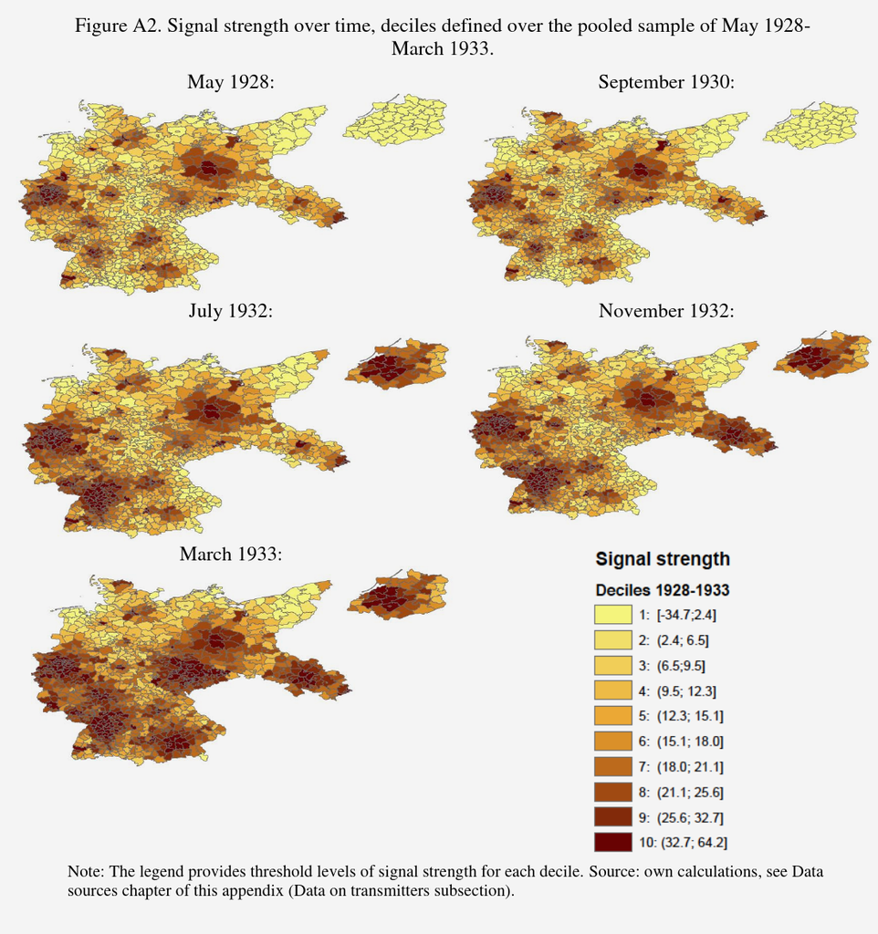

*Precincts within radius of Nazi controlled radio broadcasts were more likely to vote for Hitler, join the Nazi Party and engage in anti-Jewish deportations prior to 1942. But the effects were moderated by past anti-Semitic attitudes.*

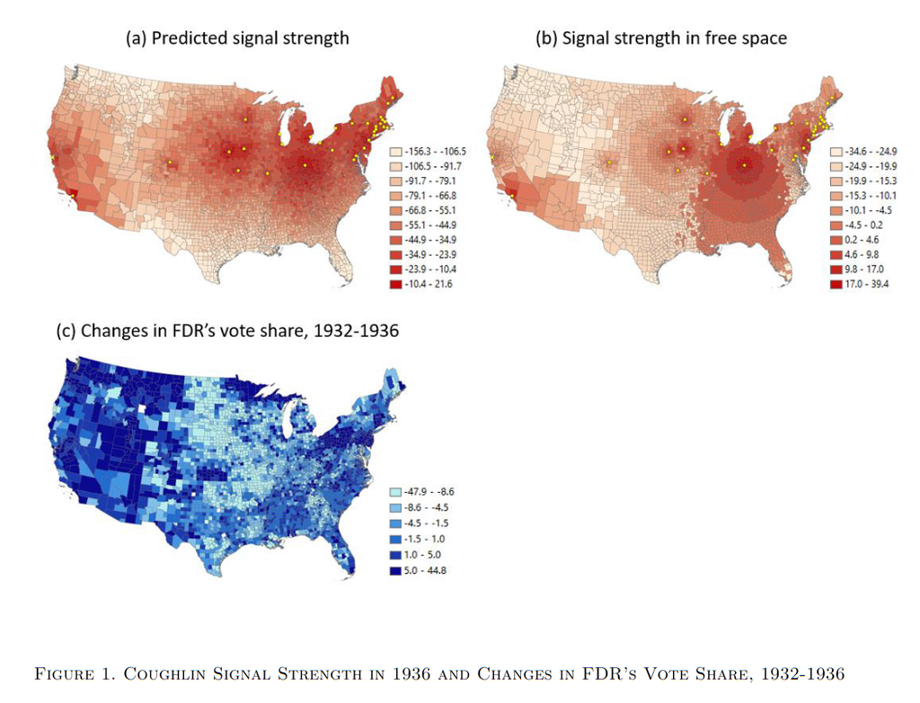

*Leveraging variation in topography (but controlling for distance) identifies negative (-2.4 p.p.) effects on FDR votes which survived even after broadcast going away from public*

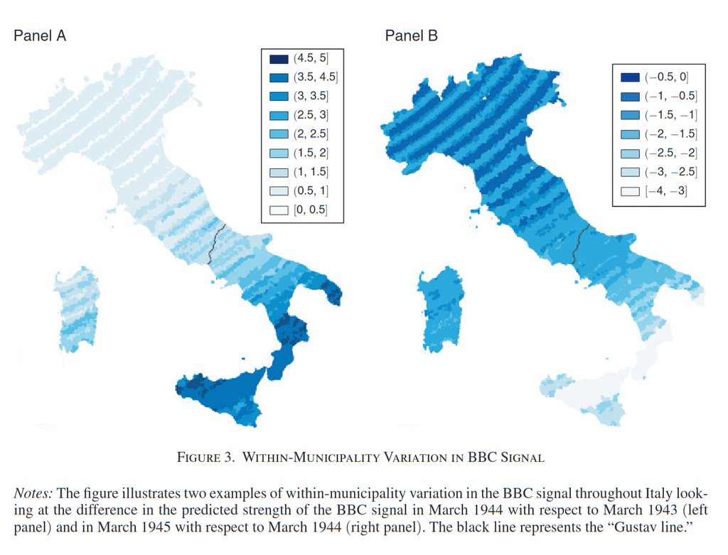

*Using sunspot activity to approximate variation in BBC radio reception finds important role of radio in motivating resistance but no long-lasting anti-Nazi effects*

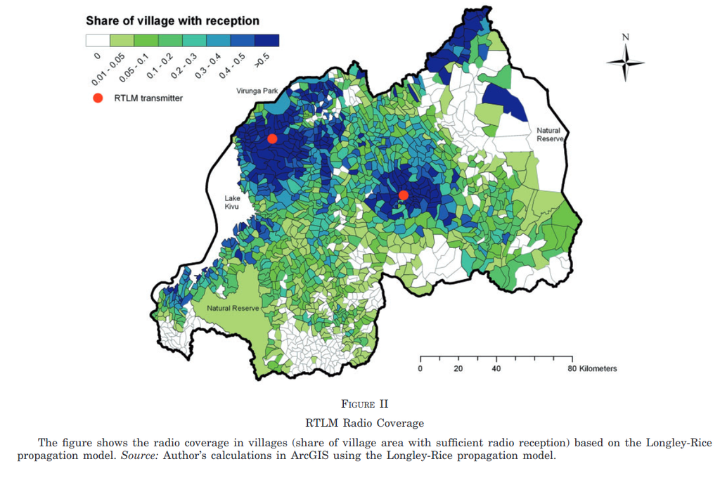

*Topographic variation in exposure to RTLM responsible for roughly 10% of killings, especially from violence requiring coordination*

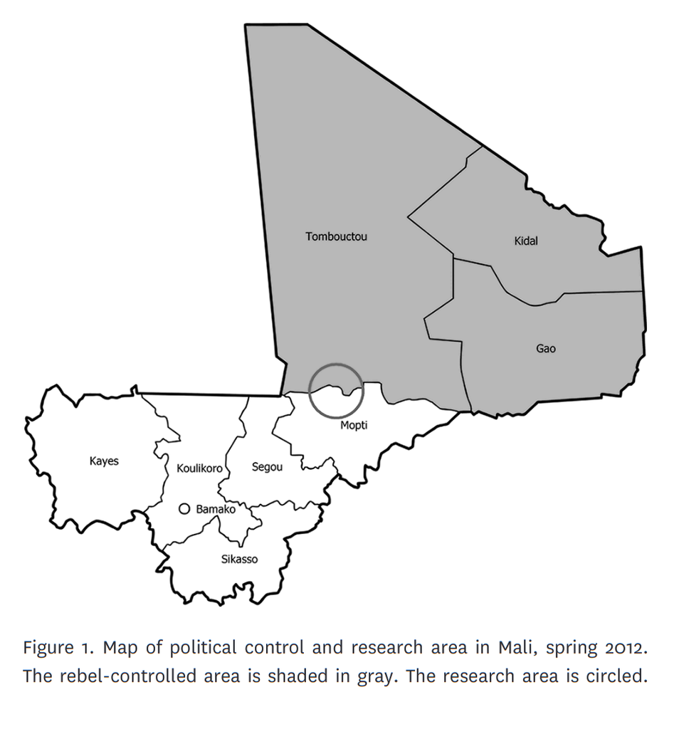

*Radio exposure boosted national identity but did not elevate explicit support for the junta*

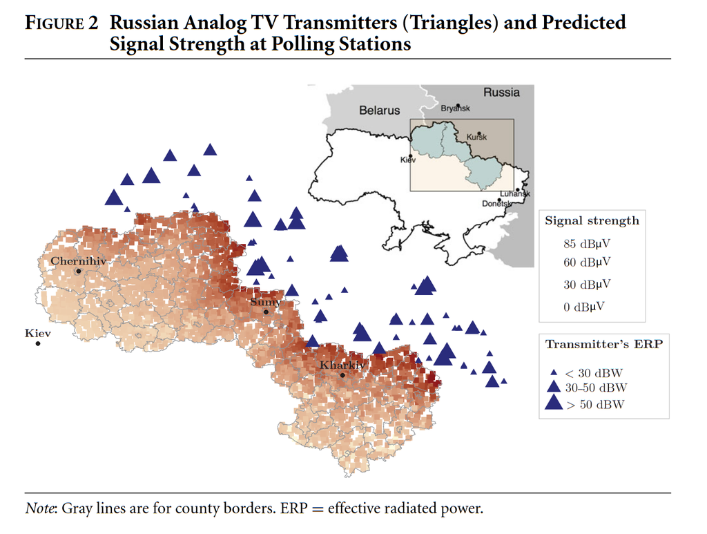

*Areas with higher cross-border exposure to Russian state media had higher support for pro-Russian parties, but no effect on turnout*

[figure not shown]

*Effects on political interest and knowledge about domestic politics but sporadic changes in attitudes on a range of gender issues (covered by radio)*

## Why does it work in theory?

- **Inattention:** System 1 (reasoning based on cues, e.g. partisanship) vs System 2 (relying on reflective and attentive reasoning)
- **Motivated reasoning:** interpreting new information to reach certain goal (also can explain consumption!)

## When does it (not) work?

- **Content:** attribution and framing are effective (Pan, Shao & Xu 2022, *PSRM*; Syunyaev 2025, *WP*)
- **Observability:** visible facts (e.g., economy, disaster management) constrain narrative power (Rosenfeld 2018, *AJPS*; Chang et al. 2022, **PNAS**)
- **Audience:** controlled information environments create both **forced** and **voluntary** exposure; even educated/skeptical can be moved (Syunyaev 2025, *WP*)
- **Backfire:** crude propaganda alienates moderates and opponents; sudden blocks spur **circumvention** (Huang 2018, *JOP*; Hobbs & Roberts 2018, *APSR*)
- **Access and state control:** search ordering, removals, flooding (Roberts 2018, *Princeton*; King, Pan & Roberts 2017, *APSR*; Stukal et al. 2017, *Big Data*) ; audiences are (more) interested in **entertainment** $\Rightarrow$ incidental exposure to propaganda (Simonov & Rao 2022, *JPE*)

## Design matters

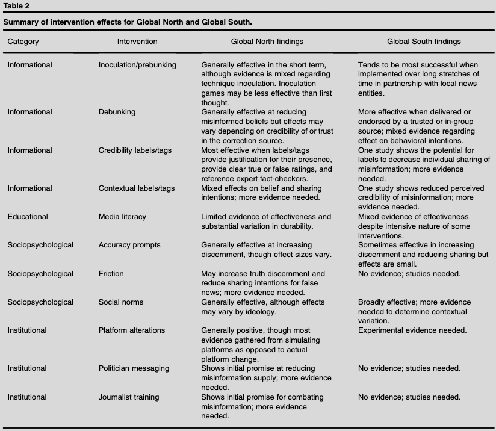

(Blair, Gottlieb, Nyhan et al. 2024, *COP*)

## Implications for democracies

- Patterns *rhyme*: slanted media persuades and polarizes.
  - Fox News entry increased GOP vote share (DellaVigna & Kaplan 2007, *QJE*)
  - Cable positions magnify persuasion/polarization (Martin & Yurukoglu 2017, *AER*)
  - Sociodemographics and partisanship predict ability to discern misinformation (Angelucci & Prat 2024, *AER*)
- But *institutions* and *plural media markets* blunt single narrative dominance (Guess 2020, *BJPS*; Guess 2021, *AJPS*) $\Rightarrow$ motivated reasoning is more important!
- **Summary:** mechanisms overlap; constraints and intensity differ and complicate the study

## Takeaways & open questions

- Propaganda (and misinformation) can be effective, but the effects are not as clear-cut
  - Effects are likely **conditional** on content, audience, environment and population level effects can be exaggerated
- We know little about what exactly works about propaganda $\Rightarrow$ not clear how to counter it (both design and targeting)
- Open questions:
  - What are the tools used by propaganda and why governments (political actors) choose them?
  - What are the implications of expansion of internet and digital tools, especially AI? (can be used for both propaganda/misinformation but also for countering it)
  - Are propaganda effects durable or they also diminish if not reinforced?
  - What leads to long-run habit change? Could be education and income, partisanship, social networks, critical thinking

## References & links

- Adena, M., Enikolopov, R., Petrova, M., Santarosa, V., Zhuravskaya, E. (2015) **AER** https://doi.org/10.1093/qje/qjv030
- Alyukov, M. (2022). **Nature Human Behavior**. https://doi.org/10.1038/s41562-022-01375-x
- Angelucci, C., & Prat, A. (2024). **AER**. https://www.aeaweb.org/articles?id=10.1257/aer.20211003
- Badrinathan, S. (2021). **APSR**. https://doi.org/10.1017/S0003055420000821
- Blair, R., Gottlieb, J., Nyhan, B., et al. (2024). **COPsych**. https://doi.org/10.1016/j.copsyc.2023.101732
- Bleck, J., & Michelitch, K. (2017). **JOP**. https://www.journals.uchicago.edu/doi/abs/10.1086/690616
- Broockman, D., & Kalla, J. (2025) **JOP**. https://www.journals.uchicago.edu/doi/full/10.1086/730725
- Chang, K-C., Hobbs, W. R., Roberts, M. E., & Steinert-Threlkeld, Z. (2022). **PNAS**. https://doi.org/10.1073/pnas.2102818119
- DellaVigna, S., & Kaplan, E. (2007). **QJE**. https://eml.berkeley.edu/~sdellavi/wp/FoxVoteQJEAug07.pdf
- Enikolopov, R., Petrova, M., & Zhuravskaya, E. (2011). **AER**. https://www.aeaweb.org/articles?id=10.1257/aer.101.7.3253
- Erlich, A., Garner, C., Pennycook, G., & Rand, D. (2023). **PolPsych**. https://doi.org/10.1111/pops.12819
- Gagliarducci, S., Nannicini, T., & Paserman, D. (2020). **AEJ:Applied**. https://www.aeaweb.org/articles?id=10.1257/app.20190410
- Green, D. P., Groves, D.W., Manda, C., Montano, B., Rahmani, B. (2024) **JOP**. https://www.journals.uchicago.edu/doi/10.1086/726964
- Guess, A. (2021). **AJPS** https://onlinelibrary.wiley.com/doi/full/10.1111/ajps.12589
- Guess, A., & Coppock, A. (2020). **BJPS** https://doi.org/10.1017/S0007123418000327
- Guriev, S., & Treisman, D. (2022). **Princeton University Press**. https://press.princeton.edu/books/hardcover/9780691211411/spin-dictators
- Hobbs, W. R., & Roberts, M. E. (2018). **APSR**. https://doi.org/10.1017/S0003055418000084
- Huang, H. (2018). **JOP**. https://www.journals.uchicago.edu/doi/abs/10.1086/696863
- King, G., Pan, J., & Roberts, M. E. (2017). **APSR**. https://doi.org/10.1017/S0003055417000144
- Krishnarajan, S., & Tolstrup J. (2023) **Science Advances** https://www.science.org/doi/full/10.1126/sciadv.adg1199
- Martin, G., & Yurukoglu, A. (2017). **AER**. https://www.aeaweb.org/articles?id=10.1257/aer.20160812
- Mattingly, D.C., Incerti, T., Ju, C., Moreshead, C., Tanaka, S., Yamagishi, H. (2025) **AJPS** https://onlinelibrary.wiley.com/doi/10.1111/ajps.12887
- Mattingly, D. C., & Yao, E. (2022). **Comparative Political Studies**. https://journals.sagepub.com/doi/10.1177/00104140211047403
- Nyhan, B., et al. (2021). **PNAS**. https://www.pnas.org/doi/10.1073/pnas.1912440117
- Pan, J., Shao, Z., Xu, Y. (2022) **PSRM** https://doi.org/10.1017/psrm.2021.35
- Paul, C., & Matthews, M. (2016). **RAND**. https://www.rand.org/pubs/perspectives/PE198.html
- Peisakhin, L., & Rozenas, A. (2018). **AJPS** https://onlinelibrary.wiley.com/doi/full/10.1111/ajps.12355
- Roberts, M. E. (2018). **Princeton University Press**. https://press.princeton.edu/books/hardcover/9780691178868/censored
- Rosenfeld, B. (2018). **AJPS**. https://onlinelibrary.wiley.com/doi/full/10.1111/ajps.12338
- Selb, P., & Munzert, S. (2018). “Examining a Most Extreme Case: Hitler’s Speeches.” **APSR**. https://doi.org/10.1017/S0003055418000424
- Shirikov, A., & Syunyaev, G. (2025). **WP**. https://gsyunyaev.com/assets/pdf/ss_attention_news.pdf
- Simonov, A., & Rao, J. (2022). **JPE** https://www.journals.uchicago.edu/doi/full/10.1086/717351
- Stukal, D., Sanovich, S., Bonneau, R., & Tucker, J. A. (2017). **Big Data**. https://www.liebertpub.com/doi/10.1089/big.2017.0038
- Syunyaev, G. (2025). **WP**. https://gsyunyaev.com/assets/pdf/syunyaev_propaganda.pdf
- Tertytchnaya, K., & Lankina, T. (2020). **JOP**. https://www.journals.uchicago.edu/doi/pdfplus/10.1086/705815
- Wang, T. (2021). **JPE**. https://www.journals.uchicago.edu/doi/10.1086/716564
- Yanagizawa-Drott, D. (2014). **QJE**. https://doi.org/10.1093/qje/qju020
- Yang, T.Z. (2025). **JOP** https://www.journals.uchicago.edu/doi/full/10.1086/734239